# Building Interactive Map for Geospatial Analysis in R

Team Algoritma

September 2, 2020

# Building Indonesia’s Static Map

*Geospatial analysis* as the main topic of our course, is a domain of analysis that focuses on data processing that is associated with geographic data. It introduces a formal techniques using geographic and geometry properties of a data. There are various business problems that can be solved using geospatial analysis, namely a few:  
- Warehouse logistics optimization  
- Market growth analysis for different regions  
- Sales demand forecasting  
- Work resource management

There are also unlisted potentials for other business domain analysis. This study focusesin extracting useful information of a geographic information into business insights. In this section we will try to learn the building blocks of a geospatial data in R by dive deeper into creating Indonesia’s static map.

## Retrieving Indonesia’s Spatial Vector

One of the most popular data types in working with geospatial is called **spatial vector**. The one we’ll be looking into is the universal standard of geospatial format developed and regulated by [Esri](https://www.esri.com/en-us/home) called **Shapefile**. Esri is known to be the international supplier of geographic information system softwares. The type format, however is then adopted by so many programming languages, including R.

Shapefile formats mainly includes 3 main files:  
- `.shp` includes the geometry data  
- `.shx` includes the index data used to identify different geometries  
- `.dbf` includes attribute information of each geometry’s data

Indonesia’s spatial vector we’ll be working with is made available by [GADM](https://gadm.org/about.html). If you went ahead to its website you can pick out different countries spatial vector. Indonesia’s spatial vector is provided up to 4 levels of granularity. In this course we’ll be working with 3 levels of spatial vector that contains:  
- Provinsi  
- Kabupaten  
- Kecamatan

The data has already been stored under `data` folder, we’ll read the data in using `readOGR()` function from `rgdal` package. The function will read any shapefile by providing the layer name of the file:

```r
idn3 <- readOGR(dsn = "data", layer = "gadm36_IDN_3")
```

Notice in the data we are reading there are additional files other than 3 mandatory files listed above:  
- `.prj` includes the information of the coordinate reference system  
- `.cpg` includes encoding information for the variable attribute stored in `.dbf` files

### Working with Spatial Vector in R

If you use the `class()` function for our newly created `idn3` object you can retrieved the SpatialPolygonsDataFrame class that is the formal spatial vector class in R:

```r
class(idn3)
```

```
#> [1] "SpatialPolygonsDataFrame"
#> attr(,"package")
#> [1] "sp"
```

To get a better idea the information stored in the object let’s go ahead and plot the object using `plot()` function:

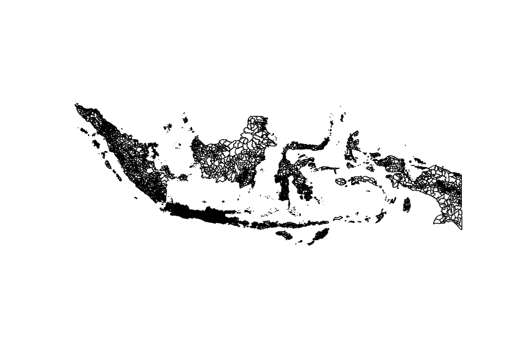

```r
plot(idn3)
```

We can see that `plot()` function is stored a spatial polygon information of Indonesia, seperated by Kecamatan. The object, is stored a a rectangular images starting on the bottom left to the top right. In geographic domain, it is common to refer the coordination system using **Latitude** and **Longitude** unit. Let’s use the `summary()` function to retrieve other informations from our object:

```r
summary(idn3)
```

```
#> Object of class SpatialPolygonsDataFrame
#> Coordinates:
#>         min        max
#> x  95.00970 141.019394
#> y -11.00762   6.076941
#> Is projected: FALSE
#> proj4string : [+proj=longlat +datum=WGS84 +no_defs]
#> Data attributes:
#>     GID_0              NAME_0             GID_1              NAME_1
#>  Length:6696        Length:6696        Length:6696        Length:6696
#>  Class :character   Class :character   Class :character   Class :character
#>  Mode  :character   Mode  :character   Mode  :character   Mode  :character
#>   NL_NAME_1            GID_2              NAME_2           NL_NAME_2
#>  Length:6696        Length:6696        Length:6696        Length:6696
#>  Class :character   Class :character   Class :character   Class :character
#>  Mode  :character   Mode  :character   Mode  :character   Mode  :character
#>     GID_3              NAME_3           VARNAME_3          NL_NAME_3
#>  Length:6696        Length:6696        Length:6696        Length:6696
#>  Class :character   Class :character   Class :character   Class :character
#>  Mode  :character   Mode  :character   Mode  :character   Mode  :character
#>     TYPE_3           ENGTYPE_3             CC_3              HASC_3
#>  Length:6696        Length:6696        Length:6696        Length:6696
#>  Class :character   Class :character   Class :character   Class :character
#>  Mode  :character   Mode  :character   Mode  :character   Mode  :character
```

Recall how we also read Coordinate Reference System (CRS) information through `.prj` file. You can singularly retrieve the information by accesing the `proj4string` slot:

```r
idn3@proj4string
```

```
#> CRS arguments: +proj=longlat +datum=WGS84 +no_defs
```

A CRS is a fundamental component of geospatial data. It models earth surface into a mathematical model. Intuitively you could think of it as a way to model a 3 dimensional surfaces such as earth, into a 2 dimensional surface that is commonly used in geospatial analysis: making maps, distance calculation, etc. Take a look at the following images for better illustration:

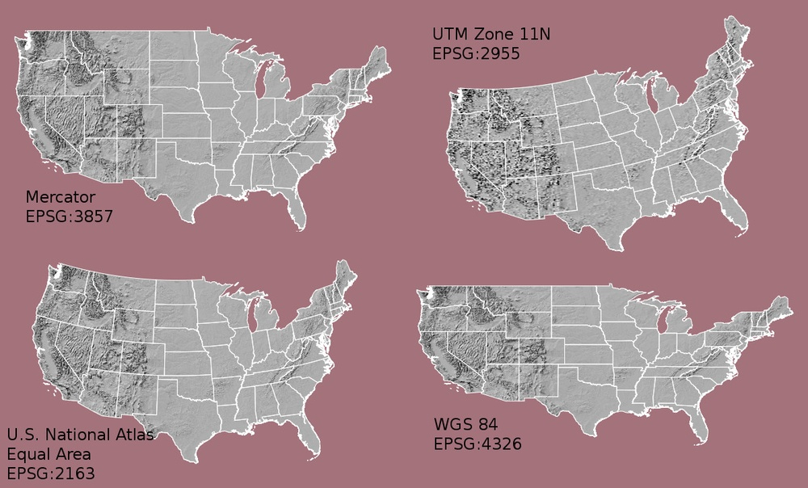

Source: https://datacarpentry.org/

If we were using geospatial data from different sources, it is important to make sure the data we are using has the same CRS attribute. A different CRS would not represented in a same mathematical space if combined and would alter any calculation done on the data significantly.

In `proj4string` format, you could see 2 main attributes printed:  
- `proj` the projection of earth angular measurement, we’ll be using a longitude and latitude  
- `datum` the model shape of earth and define the angular measurement starting points. Common ones are `WGS84` and also the one we are using on this workshop

### Joining Tables to Spatial Polygon

```r
head(idn3@data)
```

|  | GID_0 | NAME_0 | GID_1 | NAME_1 | NL_NAME_1 | GID_2 | NAME_2 | NL_NAME_2 | GID_3 | NAME_3 | VARNAME_3 | NL_NAME_3 | TYPE_3 | ENGTYPE_3 | CC_3 | HASC_3 |
| --- | --- | --- | --- | --- | --- | --- | --- | --- | --- | --- | --- | --- | --- | --- | --- | --- |
| 0 | IDN | Indonesia | IDN.1_1 | Aceh | NA | IDN.1.2_1 | Aceh Barat | NA | IDN.1.2.1_1 | Arongan Lambalek | NA | NA | Kecamatan | Sub-district | 1107062 | NA |
| 1 | IDN | Indonesia | IDN.1_1 | Aceh | NA | IDN.1.2_1 | Aceh Barat | NA | IDN.1.2.2_1 | Bubon | NA | NA | Kecamatan | Sub-district | 1107061 | NA |
| 2 | IDN | Indonesia | IDN.1_1 | Aceh | NA | IDN.1.2_1 | Aceh Barat | NA | IDN.1.2.3_1 | Johan Pahlawan | NA | NA | Kecamatan | Sub-district | 1107050 | NA |
| 3 | IDN | Indonesia | IDN.1_1 | Aceh | NA | IDN.1.2_1 | Aceh Barat | NA | IDN.1.2.4_1 | Kaway Xvi | NA | NA | Kecamatan | Sub-district | 1107080 | NA |
| 4 | IDN | Indonesia | IDN.1_1 | Aceh | NA | IDN.1.2_1 | Aceh Barat | NA | IDN.1.2.5_1 | Meureubo | NA | NA | Kecamatan | Sub-district | 1107081 | NA |
| 5 | IDN | Indonesia | IDN.1_1 | Aceh | NA | IDN.1.2_1 | Aceh Barat | NA | IDN.1.2.6_1 | Pantai Ceuremen | NA | NA | Kecamatan | Sub-district | 1107082 | NA |

It contains several column information of different levels of regions. The third level, as we can see stated in the `TYPE_3` column, stored Kecamatan information from Indonesia. Now let’s head back to our `housing_jkt` data that stores different house prices in Jadebotabek area.

```r
housing <- read.csv("data/housing_jkt.csv")
housing %>% glimpse()
```

```
#> Rows: 10,230
#> Columns: 7
#> $ id        <int> 1, 2, 3, 4, 5, 6, 7, 8, 9, 10, 11, 12, 13, 14, 15, 16, 17...
#> $ kota      <chr> "Jakarta Pusat", "Jakarta Pusat", "Jakarta Pusat", "Jakar...
#> $ kecamatan <chr> "Gambir", "Kemayoran", "Gambir", "Kemayoran", "Tanjung Pr...
#> $ harga     <dbl> 3.900e+09, 1.450e+09, 1.110e+10, 4.850e+08, 5.600e+09, 3....
#> $ KT        <int> 3, 3, 10, 2, 6, 10, 4, 6, 4, 6, 3, 2, 4, 4, 3, 7, 4, 7, 1...
#> $ KM        <int> 2, 2, 8, 1, 5, 5, 3, 5, 4, 4, 3, 1, 4, 4, 2, 6, 4, 5, 10,...
#> $ m2        <dbl> 169, 160, 720, 35, 240, 180, 150, 312, 127, 540, 81, 38, ...
```